# PSTAT 131 Final Project

## K-Nearest Neighbor Method

To prepare, we split our data again and we use the same test data to compare different models. (Why we use the same test data: When different models face the same situation, which means the same unknown data, how they perform and how high their prediction accuracy are will represent how successful the model is)

```r
set.seed(1)

#We take 80% training data and 20% testing data.
train <- sample(1:nrow(blueData), 0.8*nrow(blueData))

blueData.train <- BData[train,]
blueData.test <- BData[-train,]
```

YTrain is the true labels for blueWins on the training set XTrain is the standardized design matrix We normalized X by using “scale”

```r
YTrain = blueData.train$blueWins
XTrain = blueData.train %>% select(-blueWins) %>% scale(center = TRUE, scale = TRUE)
```

We do the same process with test level. YTest is the true labels for blueWins on the test set, and Xtest is the design matrix.

```r
YTest = blueData.test$blueWins
XTest = blueData.test %>% select(-blueWins) %>% scale(center = TRUE, scale = TRUE)
```

Note that we set a random seed before applying sample() to ensure reproducibility. We set K in a range from 1 to 50, then construct the cross validation.

This approach involves randomly dividing the set of observations into k groups, or folds, of approximately equal size. In other word, the training sample is divided into N pieces, and when k is equal to 1, we first train the model in four of them, and then test the model in the remaining one. That way, when K is equal to 1, we can train the model five times, we can get five results, and then we can get an average, which is a stable result. And then k is 2,3,4… The results of 50 were compared.

We use LOOCV to find the validation error, then tried to find the best nearest neigbor through all 1 to 50 validation errors.

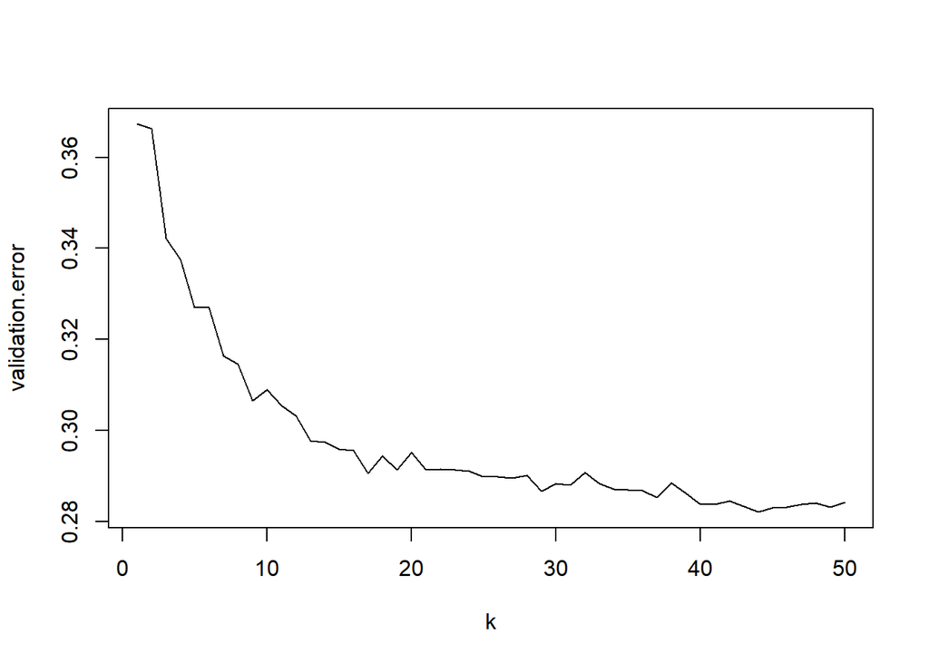

We want to find the best knn, and it is 44 for our dataset. We can also see this result from the plot above.

```r
numneighbor = max(allK[validation.error == min(validation.error)])
numneighbor
```

```
## [1] 44
```

**Calculate training error rate**

In order to get the training error, we have to train the kNN classifier on the training set and predict blueWins on the same training set, then we can construct the confusion matrix with k = 44(best K-nn we just gain) to get the training error rate.

```r
set.seed(1)
pred.YTtrain = knn(train=XTrain, test=XTrain, cl=YTrain, k=44,
                   prob = T)
```

Here is the confusion matrix for training data set.

```r
conf.train = table(predicted=pred.YTtrain, true=YTrain)
conf.train
```

```
##          true
## predicted    0    1
##         0 2972 1074
##         1 1037 2820
```

We get training error rate is 0.2671.

```r
1 - sum(diag(conf.train)/sum(conf.train))
```

```
## [1] 0.2671138
```

**Calculate test error rate**

To get the test error, we have to train the k-NN classifier on the training set and predict blueWins on the test set, then again we can construct the confusion matrix to get the test error rate.

```r
pred.YTest = knn(train=XTrain, test=XTest, cl=YTrain, k=44)
```

Here is the confusion matrix for test data set.

```r
conf.test = table(predicted=pred.YTest, true=YTest)
conf.test
```

```
##          true
## predicted   0   1
##         0 675 295
##         1 265 741
```

We get test error rate is 0.2834.

```r
1 - sum(diag(conf.test)/sum(conf.test))
```

```
## [1] 0.2834008
```

## Random Forest and Bagging

In this section, we applied both random forest model and bagging model to our data set. Since bagging is a special case of random forest, we put two models in the same section.

```r
set.seed(1)

#We take 80% training data and 20% testing data.
train <- sample(1:nrow(blueData), 0.8*nrow(blueData))

blueData.train <- BData[train,]
blueData.test <- BData[-train,]
```

**Random Forest**

```r
set.seed(1)
fit.rf<-randomForest(as.factor(blueWins) ~ .,
                     data=blueData.train,
                     mtry=4,
                     ntree=500,
                     nodesize=5,
                     importance=TRUE)
fit.rf
```

```
##
## Call:
##  randomForest(formula = as.factor(blueWins) ~ ., data = blueData.train,      mtry = 4, ntree = 500, nodesize = 5, importance = TRUE)
##                Type of random forest: classification
##                      Number of trees: 500
## No. of variables tried at each split: 4
##
##         OOB estimate of  error rate: 27.94%
## Confusion matrix:
##      0    1 class.error
## 0 2944 1065   0.2656523
## 1 1143 2751   0.2935285
```

By observing the OOB line in the plot, we can see a decreasing trend and approach to 0.28 with the increase of ntree value. As a result, we know that our ntree value choose is good to our random forest model.

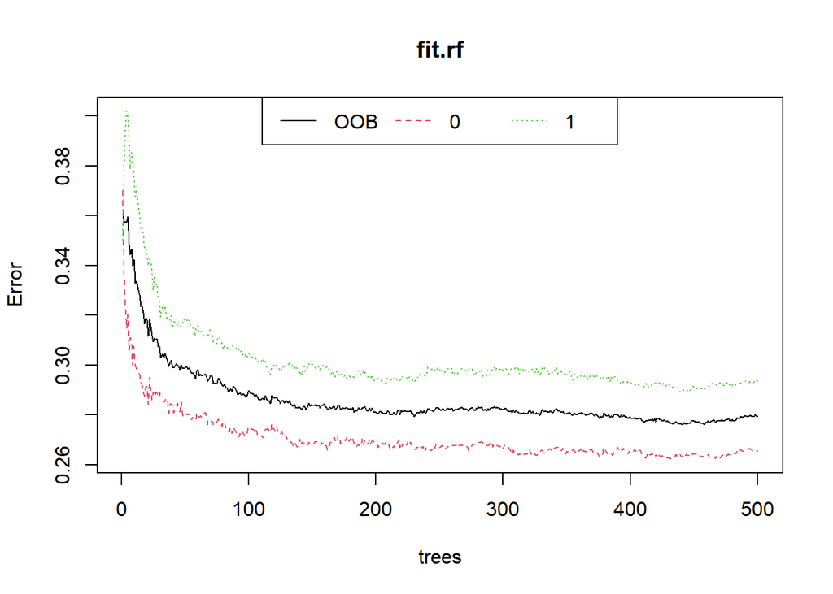

```r
plot(fit.rf)
legend("top",
       legend = colnames(fit.rf$err.rate),
       lty = 1:3,
       col = 1:3,
       horiz = T)
```

We can view the level of importance for each variable in the following two steps. Through the data and the plot, it is obvious that blueGoldDiff and blueExperienceDiff are two most important factors help blue team to win.

```r
importance(fit.rf)
```

```
##                                      0         1 MeanDecreaseAccuracy
## blueWardsPlaced               1.437957  3.004543            3.1695021
## blueWardsDestroyed            1.351695 -2.111428           -0.5402517
## blueFirstBlood                1.999796  6.734599            6.3460412
## blueKills                    10.246865 10.691031           18.8906635
## blueAssists                  20.742307  7.276808           24.0165339
## blueDragons                  16.803318 17.104674           23.5961338
## blueHeralds                   7.247633 -2.562052            3.6793425
## blueTowersDestroyed           3.499903 -2.542040            0.5988796
## blueTotalGold                21.167557 16.506582           32.4399925
## blueTotalExperience          15.466098 14.087530           24.6313010
## blueTotalMinionsKilled       11.772029  6.886440           14.3602627
## blueTotalJungleMinionsKilled  3.137044  4.697517            5.6561077
## blueGoldDiff                 43.383106 39.791487           70.5890894
## blueExperienceDiff           31.445784 25.236109           48.7994806
##                              MeanDecreaseGini
## blueWardsPlaced                    198.034195
## blueWardsDestroyed                 126.714750
## blueFirstBlood                      37.650153
## blueKills                          141.913607
## blueAssists                        163.181267
## blueDragons                         61.464924
## blueHeralds                         29.278673
## blueTowersDestroyed                  8.195208
## blueTotalGold                      406.603396
## blueTotalExperience                365.744793
## blueTotalMinionsKilled             247.608130
## blueTotalJungleMinionsKilled       210.334435
## blueGoldDiff                       796.418859
## blueExperienceDiff                 601.922752
```

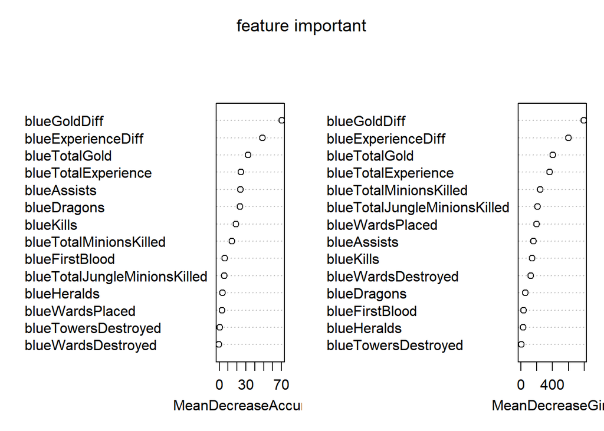

```r
varImpPlot(fit.rf,main='feature important')
```

Here is the confusion matrix for test data set.

```r
pred<-predict(fit.rf,blueData.test)
rf.err = table(pred = pred, truth = blueData.test$blueWins)
rf.err
```

```
##     truth
## pred   0   1
##    0 685 297
##    1 255 739
```

```r
test.rf.err = 1 - sum(diag(rf.err))/sum(rf.err)
test.rf.err
```

```
## [1] 0.2793522
```

The test error rate is 0.2794.

**Bagging**

We do data splitting again for a new bagging model.

```r
set.seed(1)

#We take 80% training data and 20% testing data.
train <- sample(1:nrow(blueData), 0.8*nrow(blueData))

blueData.train <- BData[train,]
blueData.test <- BData[-train,]
```

Check the structure of above data frame we just created

```r
# glimpse(blueData.train)
# str(blueData.train)
```

Here, we again set blueWins to a factor. Then, we choose *mtry* = 14 which indicates the remaining 14 predictors should be considered for each split of the tree. We used randomForest() to perform the bagging model. The confusion matrix of the training data set is as followed.

```r
blueData.train$blueWins <- as.character(blueData.train$blueWins)
blueData.train$blueWins <- as.factor(blueData.train$blueWins)

bag.rank <- randomForest(blueWins~.,
                         data = blueData.train,
                         mtry=14,
                         importance = TRUE)
bag.rank
```

```
##
## Call:
##  randomForest(formula = blueWins ~ ., data = blueData.train, mtry = 14,      importance = TRUE)
##                Type of random forest: classification
##                      Number of trees: 500
## No. of variables tried at each split: 14
##
##         OOB estimate of  error rate: 29.1%
## Confusion matrix:
##      0    1 class.error
## 0 2877 1132   0.2823647
## 1 1168 2726   0.2999486
```

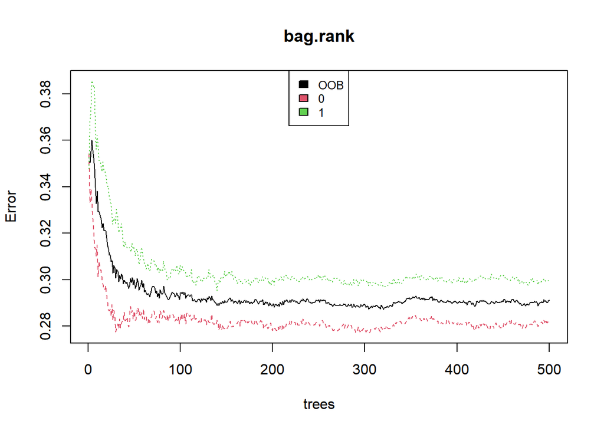

```r
plot(bag.rank)
legend("top",
       colnames(bag.rank$err.rate),
       col = 1:3,
       cex = 0.8,
       fill = 1:3)
```

We want to know how well does this bagged model perform on the test set. So, we create a confusion matrix and calculate the test error rate through it. The test error rate we get is about 0.2804.

```r
yhat.bag <- predict(bag.rank, newdata = blueData.test)
bag.err <- table(pred=yhat.bag, truth=blueData.test$blueWins)
bag.err
```

```
##     truth
## pred   0   1
##    0 681 295
##    1 259 741
```

```r
test.bag.err <- 1- sum(diag(bag.err))/sum(bag.err)
test.bag.err
```

```
## [1] 0.2803644
```

## Boosted tree

We do data splitting again for a new boosted tree model.

```r
set.seed(1)

#We take 80% training data and 20% testing data.
train <- sample(1:nrow(blueData), 0.8*nrow(blueData))

blueData.train <- BData[train,]
blueData.test <- BData[-train,]
```

When we perform the boosted tree, we use gbm() with the option distribution=“bernoulli” to fit our classification problem. We use the option interaction.depth=4 limits the depth of each tree to 4.

```r
set.seed(1)
boost.blueData = gbm(blueWins ~.,
                     data=blueData.train,
                     distribution="bernoulli",
                     n.trees=500,
                     interaction.depth=4)
```

By using the summary() function, we produces a relative influence plot and outputs the relative influence statistics. Again, it is obvious to see that blueGoldDiff and blueExperienceDiff are two most important factors when we observe the relative influence plot and statistics. Since they are important, we want to pull them out to create individual partial dependence plots for them.

```r
varimp_gbm <- summary(boost.blueData)
```

[figure not shown]

```r
varimp_gbm
```

```
##                                                       var    rel.inf
## blueGoldDiff                                 blueGoldDiff 40.1872068
## blueExperienceDiff                     blueExperienceDiff 19.3944259
## blueTotalExperience                   blueTotalExperience  8.7615628
## blueTotalGold                               blueTotalGold  8.1501696
## blueTotalMinionsKilled             blueTotalMinionsKilled  4.9021937
## blueTotalJungleMinionsKilled blueTotalJungleMinionsKilled  4.2138385
## blueWardsPlaced                           blueWardsPlaced  4.1602835
## blueAssists                                   blueAssists  2.8651439
## blueDragons                                   blueDragons  2.6004598
## blueWardsDestroyed                     blueWardsDestroyed  2.1201035
## blueKills                                       blueKills  1.5379910
## blueFirstBlood                             blueFirstBlood  0.6212946
## blueHeralds                                   blueHeralds  0.3482497
## blueTowersDestroyed                   blueTowersDestroyed  0.1370767
```

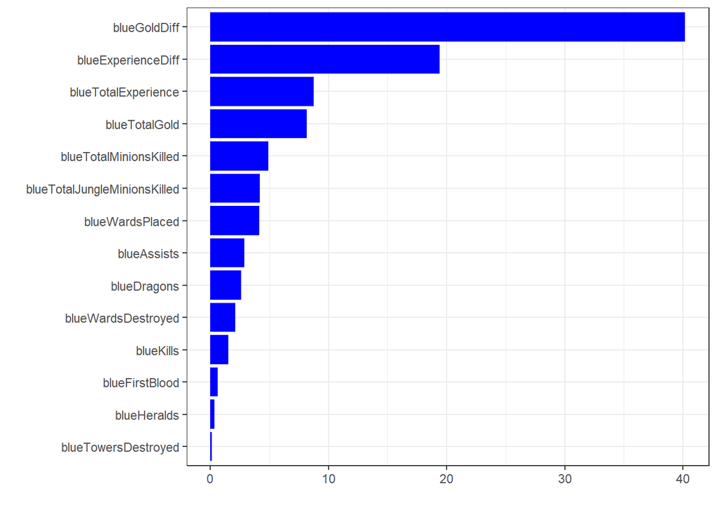

```r
varimp_gbm %>%
  arrange(rel.inf) %>%
  mutate(var = as_factor(var)) %>%
  ggplot(aes(x = rel.inf, y = var)) +
  geom_col(fill = "blue") +
  labs(x = "", y = "") +
  theme_bw()
```

This is the partial dependence plot for blueGoldDiff. As shown in the plot, the line increases greatly in the range of -5000 to 5000, which is the range that gold difference change win rate of blue team the most.

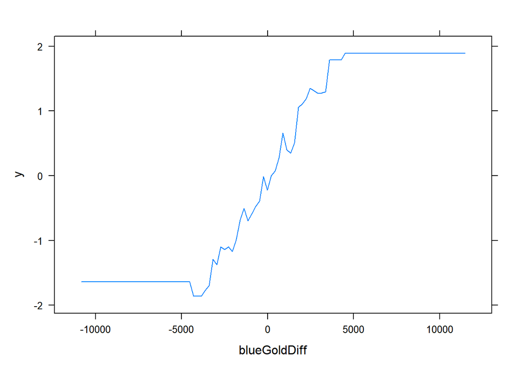

```r
plot(boost.blueData, i="blueGoldDiff")
```

This is the partial dependence plot for blueExperienceDiff. Similar to the previous plot, it also influence the win rate of blue team the most in the range of -5000 to 5000.

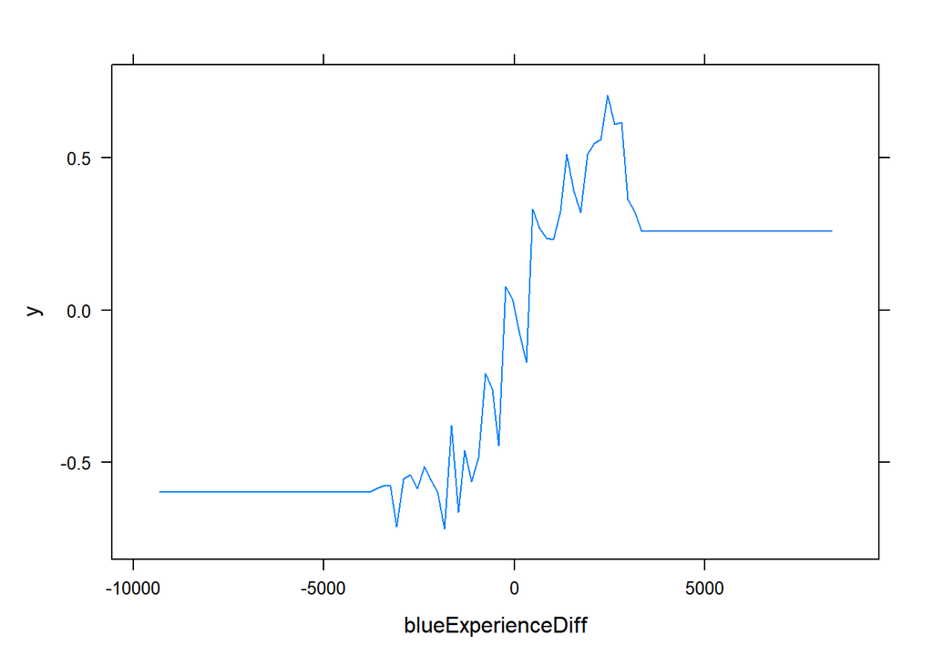

```r
plot(boost.blueData, i="blueExperienceDiff")
```

We then predict blueWins on the test data set through the boosted model. We create the confusion matrix first and then calculate the test error rate. The test error rate is about 0.3041.

```r
yhat.boost = predict(boost.blueData,
                     newdata = blueData.test,
                     n.trees=500)
pred1=as.factor(ifelse(yhat.boost>=0.5,1,0))
boost.err = table(pred = pred1, truth = blueData.test$blueWins)
boost.err
```

```
##     truth
## pred   0   1
##    0 782 443
##    1 158 593
```

```r
test.boost.err = 1 - sum(diag(boost.err))/sum(boost.err)
test.boost.err
```

```
## [1] 0.3041498
```

# Conclusion

## Summary

This study has furthered the understanding of which are the most important factors influence the win rate of a team in the first 10 minutes League of Legends rank game. After scanning the overall data, we removed the superficial unrelated variable (gameID) and some overlap high-correlated variables. In EDA part, we tried to see the whole pattern of the dataset and gave a prediction of which are the most important factors, then proved our prediction in the following model fitting. Each time we used a new model, we do the data splitting to separate data into a training set and a test set.

## Best Model

After processing all of the models to our data set, we can choose the best model by comparing the test error rates of each model. So, we create a table to make a clear comparison.

[output not shown]

The method has the highest test error rate is the boosted tree model, which perform poorly for our dataset. The method has the lowest test error rate is logistic regression, which will be our final choice for our dataset. The second low test error rate is random forest, which also perform well since it emphasizes feature selection which focus on certain features like GoldDiff and ExperienceDiff (which are proved to be important in the models) as more important than others. However, random forest perform better when there are more categorical variables, our dataset has a higher percentage of numberic variables. Logistic regression should still be the best model.

We then focus our eye on the logistic regression model. By observing the p-value table below, we can clearly see that blueDragons, blueGoldDiff, blueExperienceDiff are three variables affect the win rate of blue team the most. In addition to the goldDiff and experienceDiff we mentioned before, the blueDragon, which only appears once in the first ten minutes, can greatly improve the strength of the whole team if they can kill it. So, blueDragon is also important.

| Variables | Pr(>$\|z\|$) |
| --- | --- |
| blueWardsPlaced | 0.210 |
| blueWardsDestroyed | 0.568 |
| blueFirstBlood | 0.117 |
| blueKills | 0.359 |
| blueAssists | 0.287 |
| blueDragons | < 2e-16 |
| blueHeralds | 0.903 |
| blueTowersDestroyed | 0.153 |
| blueTotalGold | 0.136 |
| blueTotalExperience | 0.780 |
| blueTotalMinionsKilled | 0.220 |
| blueTotalJungleMinionsKilled | 0.498 |
| blueGoldDiff | < 2e-16 |
| blueExperienceDiff | 2.74e-09 |

## Interesting things and Further Study

It is interesting to see that killing enemies (which is the KDA) does not affect much on the direction of the whole game. Since the dataset used in research collect data from games of the top “High-Elo players” who are really familiar with the games. They have consistent tactics, big picture of the overall situation ,and usually fight with similar players due to the ranking mechanism of LOL. The result of this study is more suitable for high-rank games. For the further study, it is more helpful and interesting to add data from lower-rank games to see how the influential factors change or not in a broader game environment.

## Overall conclusion

In conclusion, the study of the league of legends diamond rank game data provide the interaction of win rate for blue team with several influential variables, resulting in an interesting outcome for diamond rank game players to predict the direction of wining during the game.

# Reference

1. Figure is from [https://en.wikipedia.org/wiki/League_of_Legends]
2. Introduction is from [https://www.leagueoflegends.com/en-us/how-to-play/]
3. Data set is from [https://www.kaggle.com/bobbyscience/league-of-legends-diamond-ranked-games-10-min]
4. The introduction video of League of Legends is from [https://www.youtube.com/watch?v=BGtROJeMPeE]
5. Lecture slides and labs.